# MAP654I - Practical introduction to Machine Learning

## Practical Session 3 - Classification

```python
import numpy as np
import pylab as pl
import scipy as sp
import seaborn as sns
import pandas as pd
```

# I- Pima data

## I.1- Load, visualize, preprocess the data

```python
pima_dataset = np.load('pima.npz')
```

```python
for column_name in pima_dataset:
    print(column_name)
```

```
xall
yall
varnames
```

```python
x1_all = pima_dataset['xall']
y1_all = pima_dataset['yall']
varnames_pima = pima_dataset['varnames']
```

```python
print('Pima Varnnames: ',list(varnames_pima))
print('x1 shape: ',x1_all.shape)
print('y1 shape: ',y1_all.shape)
```

```
Pima Varnnames:  ['Pregnancies', 'Glucose', 'BloodPressure', 'SkinThickness', 'Insulin', 'BMI', 'DiabetesPedigreeFunction', 'Age']
x1 shape:  (709, 8)
y1 shape:  (709,)
```

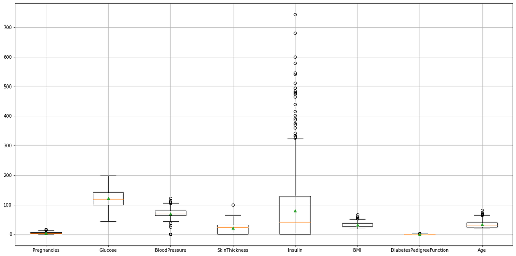

```python
fig = pl.figure(1, figsize=(20, 10))
boxplot = pl.boxplot(x1_all,showmeans=True)
boxplot_label = pl.xticks([i+1 for i in range(len(varnames_pima))],varnames_pima)
pl.grid()
pl.title("",fontsize=15)
pl.ylabel("")
```

The variables are very diverse. They must be normalized. Insulin is measured in µUI/mL, its maximum is more than 700 in the dataset. Other variables like 'BMI' have a lower interquartile range.

It is therefore necessary to normalize the data to homogenize the scales between the variables.

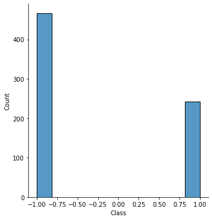

```python
sns.displot(y1_all)
pl.xlabel("Class")
```

On this graph, we can see the distribution of data y. 1 corresponds to a patient who is diabetic and -1 who is not.

It can be noted that there are more non-diabetic patients, which is reassuring. However, this dataset is not necessarily representative of the population. In France, 1 person out of 10 has diabetes, according to this site: http://ceed-diabete.org/fr/le-diabete/les-chiffres/.

```python
data = []
for i in range(len(x1_all)):
    data.append(np.append(x1_all[i],y1_all[i]))
data = np.array(data)
```

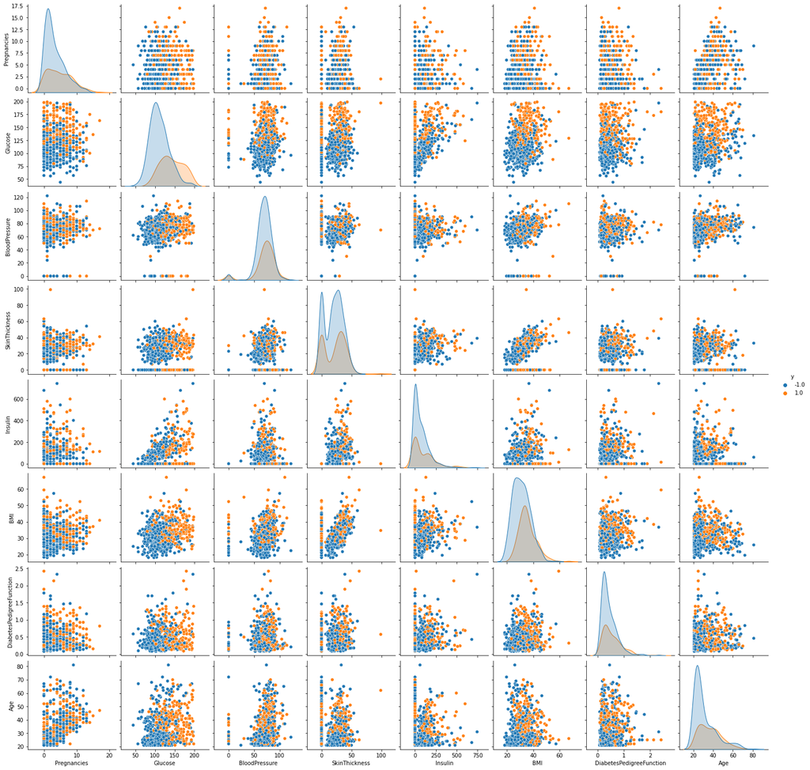

```python
sns.pairplot(pd.DataFrame(data, columns=np.append(varnames_pima,'y')), hue='y', palette="tab10")
```

Thanks to this pairplot between all the variables, we can try to predict which variables can help us to predict diabete. For this, we put colors according to the real classes (diabetes and non-diabetes).

We can then try to locate the scatter plot where the two classes are clearly separable. For example the variable glucose seems to be very important. If we look at any variable as a function of glucose, the two colors are clearly separated. This indicates that looking at a patient's glucose level can help a lot to conclude about the person's diabetes.

On the diagonal, we can see the distribution of each variable in a histogram. With all this informations we can make these assumptions:

For a medical vision, I did some research and asked some health professionals. The main factor of diabetes is glucose. A doctor concludes about a patient's diabetes by looking at his fasting glucose level and over time. A diabetic patient has hyperglycemia. So it is not surprising to see in our dataset that sugar has a very important place in predicting diabetes. However, the other variables are also (secondary) factors of Diabetes.

- Insulin : Hormone that lowers blood sugar.
- BMI : body mass index, according to my research people with diabetes sometimes have a higher BMI.

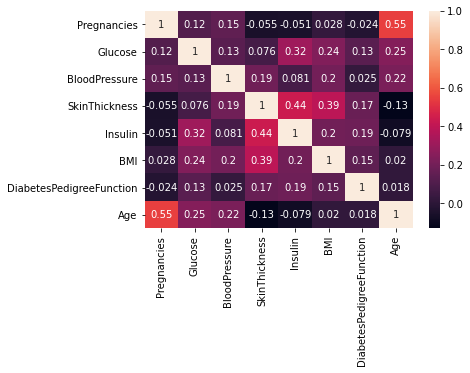

```python
sns.heatmap(np.corrcoef(x1_all.T),annot=True,xticklabels=varnames_pima,yticklabels=varnames_pima)
```

On this correlation matrix we can see that insulin is very correlated with the thinness of the skin. Skin thinness may be a secondary factor of diabetes, i.e. this variable may not be directly related to diabetes but is a consequence of it.

```python
x1_train, x1_test = x1_all[:300],x1_all[300:]
y1_train, y1_test = y1_all[:300],y1_all[300:]
```

```python
print('x1_train shape: ',x1_train.shape)
print('y1_train shape: ',y1_train.shape)
print('-----')
print('x1_test shape: ',x1_test.shape)
print('y1_test shape: ',y1_test.shape)
```

```
x1_train shape:  (300, 8)
y1_train shape:  (300,)
-----
x1_test shape:  (409, 8)
y1_test shape:  (409,)
```

```python
print('Var. before scaling',np.std(x1_train, axis=0))
print('Range of values before scaling',np.ptp(x1_train, axis=0))
```

```
Var. before scaling [  3.32471553  30.01834162  17.89310078  15.65371486 116.09784547
   7.28910298   0.32931533  10.84544144]
Range of values before scaling [ 17.    153.    122.     60.    744.     48.7     2.251  48.   ]
```

Before normalization, the standard deviation and the range of our variables are very different. We can't apply algorithms now, we have to normalize.

```python
from sklearn.preprocessing import StandardScaler
scaler = StandardScaler()
x1_train = scaler.fit_transform(x1_train)
x1_test = scaler.fit_transform(x1_test)
```

```python
print('Var. before scaling',np.std(x1_train, axis=0))
print('Range of values before scaling',np.ptp(x1_train, axis=0))
```

```
Var. before scaling [1. 1. 1. 1. 1. 1. 1. 1.]
Range of values before scaling [5.11321942 5.09688383 6.81827043 3.83295598 6.40838766 6.6812062
 6.83539395 4.42582262]
```

Now all variances are equal to 1, the ranges are almost equal. It is important to have identical scales between our variables to be able to compare them.

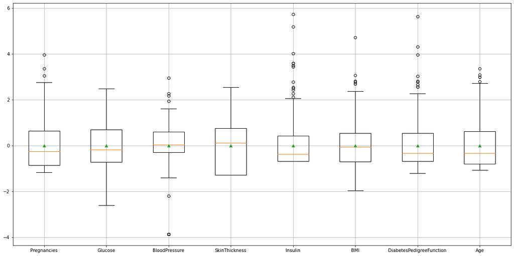

```python
fig = pl.figure(1, figsize=(20, 10))
boxplot = pl.boxplot(x1_train,showmeans=True)
boxplot_label = pl.xticks([i+1 for i in range(len(varnames_pima))],varnames_pima)
pl.grid()
pl.title("",fontsize=15)
pl.ylabel("")
```

It is a problem to not have the same scaling and variances. Indeed, without normalizer we could not compare the variables. In addition, it prevents an algorithm from valuing one variable over another because it has higher values.

## I.2- Bayesian decision and linear classification

Let's create a dataframe in order to store the performance mesures of our algorithms.

```python
import pandas as pd
from tabulate import tabulate

data = {'Algorithm':[],

        'Accuracy (test set)': [],
        'AUC (test set)':[]
       }

df_pima = pd.DataFrame(data)

def print_all_measures_pima():
    print(tabulate(round(df_pima, 2), headers='keys', tablefmt='pretty',showindex=False))
```

```python
from sklearn.metrics import accuracy_score, roc_auc_score

def print_performance_on_test_pima(clf, df ,algorithm_name_for_df_save=''):
    accuracy = accuracy_score(y1_test, clf.predict(x1_test))
    auc      = roc_auc_score(y1_test, clf.predict_proba(x1_test)[:,1])
    print('Accuracy on test = ', accuracy)
    print('AUC on test      = ', auc)

    if len(algorithm_name_for_df_save) > 0:
        df = df.append({'Algorithm' : algorithm_name_for_df_save,

                'Accuracy (test set)' : accuracy,
                'AUC (test set)' : auc
               }, ignore_index=True)
        return df
```

### Linear Discriminant Analysis (LDA)

LDA is a linear classifier.

```python
from sklearn.discriminant_analysis import LinearDiscriminantAnalysis
```

```python
LDA = LinearDiscriminantAnalysis()
LDA.fit(x1_train, y1_train)
df_pima = print_performance_on_test_pima(LDA, df_pima,'LDA default')
```

```
Accuracy on test =  0.8117359413202934
AUC on test      =  0.8619680560113773
```

We can see that even with the default settings we get very good results.

```python
from sklearn.model_selection import GridSearchCV
param_grid = {'solver' : ['lsqr', 'eigen'],
             'shrinkage' : np.linspace(0,1,100)}
grid_search_LDA = GridSearchCV(LDA, param_grid=param_grid,scoring='roc_auc')
no_display = grid_search_LDA.fit(x1_train, y1_train)
```

**Note:** I decided to run all my GridGearch with the AUC score so I can get a little difference in the results.

```python
grid_search_LDA.best_params_
```

```
{'shrinkage': 0.4545454545454546, 'solver': 'lsqr'}
```

```python
LDA = LinearDiscriminantAnalysis(shrinkage=grid_search_LDA.best_params_['shrinkage'],
                                 solver=grid_search_LDA.best_params_['solver'])
LDA.fit(x1_train, y1_train)
df_pima = print_performance_on_test_pima(LDA, df_pima,'LDA')
```

```
Accuracy on test =  0.8166259168704156
AUC on test      =  0.8679302045728038
```

81% of patients are well classified. This is a good result, changing the parameters did not greatly improve the results. But the choice of a linear classifier seems to be adequate for this problem.

```
(0, 'Pregnancies')
(1, 'Glucose')
(2, 'BloodPressure')
(3, 'SkinThickness')
(4, 'Insulin')
(5, 'BMI')
(6, 'DiabetesPedigreeFunction')
(7, 'Age')
```

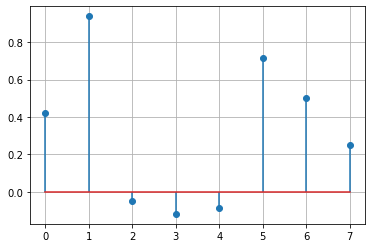

```python
pl.stem(LDA.coef_[0])
pl.grid()
for elt in enumerate(varnames_pima):
    print(elt)
```

The highest weight was placed on glucose. This seems to be a very good choice from a medical point of view. The second one was placed on BMI which also seems to be consistent.

An other important weight is observed for pregancies and Age. For age, the older you get, the more likely you are to eat bad things or to become overweight and therefore diabetic. So it can make sense. But for pregnancies I see no link with diabetes. Maybe there is a medical link that I don't know about, or maybe the algorithm has detected a link in the dataset that doesn't exist in real life.

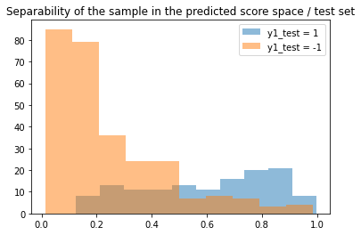

```python
pl.hist(LDA.predict_proba(x1_test)[y1_test==1,1], label='y1_test = 1', alpha=0.5)
pl.hist(LDA.predict_proba(x1_test)[y1_test==-1,1], label='y1_test = -1', alpha=0.5)
pl.title('Separability of the sample in the predicted score space / test set')
fig = pl.legend()
```

This graph is interesting. You can see the distribution of the probability returned by LDA. This distribution is cut in two according to the patients who really have diabetes and those who do not.

Knowing that the algorithm chooses the categorial prediction with the probability threshold of 0.5, this graph allows to visualize the false predictions. If the algorithm had been perfect, the two histograms would not touch. We can even say that the false negative rate looks important, it's very bad for a medical application of this type. We will analyze this problem later in the lab.

```python
print_all_measures_pima()
```

```
+-------------+---------------------+----------------+
|  Algorithm  | Accuracy (test set) | AUC (test set) |
+-------------+---------------------+----------------+
| LDA default |        0.81         |      0.86      |
|     LDA     |        0.82         |      0.87      |
+-------------+---------------------+----------------+
```

Changing the parameters allowed us to gain 1% in accuracy on test set.

### Quadratic Discriminant Analysis (QDA)

QDA is a classifier with a quadratic decision boundary, Let's see if we can have better results than LDA.

```python
from sklearn.discriminant_analysis import QuadraticDiscriminantAnalysis
```

```python
QDA = QuadraticDiscriminantAnalysis()
QDA.fit(x1_train, y1_train)
df_pima = print_performance_on_test_pima(QDA, df_pima,'QDA default')
```

```
Accuracy on test =  0.7481662591687042
AUC on test      =  0.8092385953396783
```

The default parameters give much worse results than LDA.

```python
param_grid = {'reg_param' : np.linspace(0,1,100)}
grid_search_QDA = GridSearchCV(QDA, param_grid=param_grid, scoring='roc_auc')
no_display = grid_search_QDA.fit(x1_train, y1_train)
```

```python
grid_search_QDA.best_params_
```

```
{'reg_param': 0.8282828282828284}
```

Grid Search returns the best value for the reg_param parameter.

```python
QDA = QuadraticDiscriminantAnalysis(reg_param=grid_search_QDA.best_params_['reg_param'])
QDA.fit(x1_train, y1_train)
df_pima = print_performance_on_test_pima(QDA, df_pima,'QDA')
```

```
Accuracy on test =  0.7995110024449877
AUC on test      =  0.8626517886445684
```

Thanks to the change of the parameter, we manage to obtain a much more correct performance.

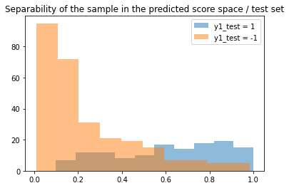

```python
pl.hist(QDA.predict_proba(x1_test)[y1_test==1,1], label='y1_test = 1', alpha=0.5)
pl.hist(QDA.predict_proba(x1_test)[y1_test==-1,1], label='y1_test = -1', alpha=0.5)
pl.title('Separability of the sample in the predicted score space / test set')
fig = pl.legend()
```

The performance indices have decreased compared to LDA but we have the impression that the false negative rate is lower. For medical use, it would be necessary to know whether a physician would prefer to have a lower accuracy or a lower false negative rate.

```python
print_all_measures_pima()
```

```
+-------------+---------------------+----------------+
|  Algorithm  | Accuracy (test set) | AUC (test set) |
+-------------+---------------------+----------------+
| LDA default |        0.81         |      0.86      |
|     LDA     |        0.82         |      0.87      |
| QDA default |        0.75         |      0.81      |
|     QDA     |         0.8         |      0.86      |
+-------------+---------------------+----------------+
```

The results are close but the LDA performs better using the AUC and accuracy indices. This could have been predicted from the initial pairplot. On some scatterplots, the two classes were visually linearly separable.

### Gaussian Naive Bayes classifier

```python
from sklearn.naive_bayes import GaussianNB
```

```python
NB = GaussianNB()
NB.fit(x1_train, y1_train)
df_pima = print_performance_on_test_pima(NB, df_pima,'NB default')
```

```
Accuracy on test =  0.7652811735941321
AUC on test      =  0.8309265944645006
```

```python
print_all_measures_pima()
```

```
+-------------+---------------------+----------------+
|  Algorithm  | Accuracy (test set) | AUC (test set) |
+-------------+---------------------+----------------+
| LDA default |        0.81         |      0.86      |
|     LDA     |        0.82         |      0.87      |
| QDA default |        0.75         |      0.81      |
|     QDA     |         0.8         |      0.86      |
| NB default  |        0.77         |      0.83      |
+-------------+---------------------+----------------+
```

LDA and QDA perform better than Naive Bayes according to the results.

Nauve Bayes classifier assumes the independence of the variables, which is false in our example. We have seen it with the correlation matrix. For example, insulin is related to the thinness of the skin. This may explain why naive bayes is not very efficient here.

### Logistic regression classifier

```python
from sklearn.linear_model import LogisticRegression
```

```python
LR = LogisticRegression()
LR.fit(x1_train, y1_train)
df_pima = print_performance_on_test_pima(LR, df_pima,'LR default')
```

```
Accuracy on test =  0.80440097799511
AUC on test      =  0.862296247675309
```

The results are good but let's look for the best parameters:

```python
param_grid = {'C' : np.logspace(-1,2,100),
              'penalty': ['l1'],
              'solver' : ['liblinear', 'saga']}
grid_search_LR = GridSearchCV(LR, param_grid=param_grid, scoring='roc_auc')
no_display = grid_search_LR.fit(x1_train, y1_train)
```

```python
grid_search_LR.best_params_
```

```
{'C': 0.11497569953977356, 'penalty': 'l1', 'solver': 'liblinear'}
```

```python
LR = LogisticRegression(C=grid_search_LR.best_params_['C'],
                        penalty=grid_search_LR.best_params_['penalty'],
                        solver=grid_search_LR.best_params_['solver'])
LR.fit(x1_train, y1_train)
df_pima = print_performance_on_test_pima(LR, df_pima,'LR')
```

```
Accuracy on test =  0.7921760391198044
AUC on test      =  0.8679302045728039
```

What can be noted here is that I did the grid search with the AUC score. The parameters indeed increase the auc score but decreased the accuracy.

```
(0, 'Pregnancies')
(1, 'Glucose')
(2, 'BloodPressure')
(3, 'SkinThickness')
(4, 'Insulin')
(5, 'BMI')
(6, 'DiabetesPedigreeFunction')
(7, 'Age')
```

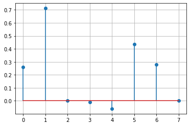

```python
pl.stem(LR.coef_[0])
pl.grid()
for elt in enumerate(varnames_pima):
    print(elt)
```

Compared to LDA, age is not taken into account at all, insulin much less. Glucose is still the most important variable, which makes sense from a medical perspective. The variable DiabetesPedigreeFunction also seems to be important. There always seems to be a link between being pregnant and having diabetes. I still don't know if this link is a particularity of the dataset or if it is also a reality.

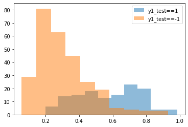

```python
pl.hist(LR.predict_proba(x1_test)[y1_test==1,1], label='y1_test==1', alpha=0.5)
pl.hist(LR.predict_proba(x1_test)[y1_test==-1,1], label='y1_test==-1', alpha=0.5)
LR_predict_proba_default_intercept = LR.predict_proba(x1_test)
fig = pl.legend()
```

The number of false negatives seems to be much higher than the previous algorithms. On the other hand the number of false positives is reduced.

Thanks to this dataset, we can see that there is not only the performance index (like accuracy) to evaluate an algortihme. Depending on the problem to solve, there are many other indicators that can be taken into account. For this problem, the false negative indicator is extremely important, I would even say more important than the accuracy.

```python
print_all_measures_pima()
```

```
+-------------+---------------------+----------------+
|  Algorithm  | Accuracy (test set) | AUC (test set) |
+-------------+---------------------+----------------+
| LDA default |        0.81         |      0.86      |
|     LDA     |        0.82         |      0.87      |
| QDA default |        0.75         |      0.81      |
|     QDA     |         0.8         |      0.86      |
| NB default  |        0.77         |      0.83      |
| LR default  |         0.8         |      0.86      |
|     LR      |        0.79         |      0.87      |
+-------------+---------------------+----------------+
```

The best results are obtained with LDA and LR (linear) than with quadratic algorithms, but there is not a big gap.

If we just look at the performance indicators, LDA is so far the best.

## I.3- Nonlinear methods

### RandomForestClassifier

```python
from sklearn.ensemble import RandomForestClassifier
```

```python
random_forest_classifier = RandomForestClassifier()
```

```python
random_forest_classifier.fit(x1_train, y1_train)
```

```
RandomForestClassifier()
```

```python
df_pima = print_performance_on_test_pima(random_forest_classifier, df_pima,'RandomForestClassifier default')
```

```
Accuracy on test =  0.7750611246943765
AUC on test      =  0.8558007876599933
```

```python
param_grid = {
    'n_estimators': [100, 200 ,300],
    'max_features': ['auto', 'sqrt', 'log2'],
    'max_depth' : [4,5,6],
    'criterion' :['gini', 'entropy']
}
```

```python
grid_search_random_forest_classifier = GridSearchCV(random_forest_classifier, param_grid=param_grid, scoring='roc_auc')
no_display = grid_search_random_forest_classifier.fit(x1_train, y1_train)
```

```python
grid_search_random_forest_classifier.best_params_
```

```
{'criterion': 'entropy',
 'max_depth': 4,
 'max_features': 'log2',
 'n_estimators': 200}
```

```python
random_forest_classifier = RandomForestClassifier(criterion = grid_search_random_forest_classifier.best_params_['criterion'],
                                                 max_depth = grid_search_random_forest_classifier.best_params_['max_depth'],
                                                 max_features = grid_search_random_forest_classifier.best_params_['max_features'],
                                                 n_estimators = grid_search_random_forest_classifier.best_params_['n_estimators'])
random_forest_classifier.fit(x1_train, y1_train)
df_pima = print_performance_on_test_pima(random_forest_classifier , df_pima,'RandomForestClassifier ')
```

```
Accuracy on test =  0.7897310513447433
AUC on test      =  0.8697352587244285
```

Random forest seems to be better on this dataset than in the last lab. We can even gain in performance by changing the parameters.

### SVC

```python
from sklearn.svm import SVC
```

```python
svc = SVC(probability=True)
```

```python
svc.fit(x1_train, y1_train)
```

```
SVC(probability=True)
```

```python
df_pima = print_performance_on_test_pima(svc, df_pima,'SVC default')
```

```
Accuracy on test =  0.7921760391198044
AUC on test      =  0.8406082485504868
```

```python
param_grid = {'C': [0.1, 1, 10, 100, 1000],
              'gamma': [1, 0.1, 0.01, 0.001, 0.0001],
              'kernel': ['rbf']}
```

```python
grid_search_svc = GridSearchCV(svc, param_grid=param_grid, scoring='roc_auc')
no_display = grid_search_svc.fit(x1_train, y1_train)
```

```python
grid_search_svc.best_params_
```

```
{'C': 1, 'gamma': 0.01, 'kernel': 'rbf'}
```

```python
svc = SVC(probability=True,
         C = grid_search_svc.best_params_['C'],
         gamma = grid_search_svc.best_params_['gamma'],
         kernel = grid_search_svc.best_params_['kernel'],)
svc.fit(x1_train, y1_train)
df_pima = print_performance_on_test_pima(svc, df_pima,'SVC')
```

```
Accuracy on test =  0.80440097799511
AUC on test      =  0.8657012361886007
```

SVC is a little bit better than Random Forest.

### MLP Classifier

```python
from sklearn.neural_network import MLPClassifier
```

```python
mlp_classifier = MLPClassifier(random_state=0, max_iter=3000)
```

```python
mlp_classifier.fit(x1_train, y1_train)
```

```
MLPClassifier(max_iter=3000, random_state=0)
```

```python
df_pima = print_performance_on_test_pima(mlp_classifier, df_pima,'MLP default')
```

```
Accuracy on test =  0.7652811735941321
AUC on test      =  0.8164588119461766
```

```python
param_grid = {'solver': ['adam', 'sgd'],
              'max_iter': [3000],
              'random_state' : [0],
              'alpha': np.logspace(-5,-1,10),
              'hidden_layer_sizes':np.arange(10, 16,2)
             }
```

```python
grid_search_mlp = GridSearchCV(mlp_classifier, param_grid=param_grid, scoring='roc_auc')
no_display = grid_search_mlp.fit(x1_train, y1_train)
```

```python
grid_search_mlp.best_params_
```

```
{'alpha': 0.1,
 'hidden_layer_sizes': 12,
 'max_iter': 3000,
 'random_state': 0,
 'solver': 'adam'}
```

```python
mlp_classifier = MLPClassifier(max_iter=2000,
                              alpha = grid_search_mlp.best_params_['alpha'],
                              solver = grid_search_mlp.best_params_['solver'],
                              hidden_layer_sizes = grid_search_mlp.best_params_['hidden_layer_sizes'])
mlp_classifier.fit(x1_train, y1_train)
df_pima = print_performance_on_test_pima(mlp_classifier, df_pima,'MLP')
```

```
Accuracy on test =  0.78239608801956
AUC on test      =  0.8295591291981184
```

MLP is not good at all comparing to other non linear algorithms.

### Gradient Boosting Classifier

```python
from sklearn.ensemble import GradientBoostingClassifier
```

```python
gradient_boosting_classifier = GradientBoostingClassifier()
```

```python
gradient_boosting_classifier.fit(x1_train, y1_train)
```

```
GradientBoostingClassifier()
```

```python
df_pima = print_performance_on_test_pima(gradient_boosting_classifier, df_pima,'GBC default')
```

```
Accuracy on test =  0.7481662591687042
AUC on test      =  0.8249370965977464
```

```python
param_grid = {
    "learning_rate": [0.01, 0.025, 0.05, 0.075, 0.1, 0.15, 0.2],
    "max_depth":[1,3,5,8],
    "max_features":["log2","sqrt"]
    }
```

```python
grid_search_gbc = GridSearchCV(gradient_boosting_classifier, param_grid=param_grid, scoring='roc_auc')
no_display = grid_search_gbc.fit(x1_train, y1_train)
```

```python
grid_search_gbc.best_params_
```

```
{'learning_rate': 0.075, 'max_depth': 1, 'max_features': 'log2'}
```

```python
gradient_boosting_classifier = GradientBoostingClassifier(learning_rate = grid_search_gbc.best_params_['learning_rate'],
                                                         max_depth = grid_search_gbc.best_params_['max_depth'],
                                                         max_features = grid_search_gbc.best_params_['max_features'])
gradient_boosting_classifier.fit(x1_train, y1_train)
df_pima = print_performance_on_test_pima(gradient_boosting_classifier, df_pima,'GBC')
```

```
Accuracy on test =  0.7701711491442543
AUC on test      =  0.8495514713926267
```

Finally, gradient boosting is not good also with this data.

## I.4- Comparison and interpretation

```python
print_all_measures_pima()
```

```
+--------------------------------+---------------------+----------------+
|           Algorithm            | Accuracy (test set) | AUC (test set) |
+--------------------------------+---------------------+----------------+
|          LDA default           |        0.81         |      0.86      |
|              LDA               |        0.82         |      0.87      |
|          QDA default           |        0.75         |      0.81      |
|              QDA               |         0.8         |      0.86      |
|           NB default           |        0.77         |      0.83      |
|           LR default           |         0.8         |      0.86      |
|               LR               |        0.79         |      0.87      |
| RandomForestClassifier default |        0.78         |      0.86      |
|     RandomForestClassifier     |        0.79         |      0.87      |
|          SVC default           |        0.79         |      0.84      |
|              SVC               |         0.8         |      0.87      |
|          MLP default           |        0.77         |      0.82      |
|              MLP               |        0.78         |      0.83      |
|          GBC default           |        0.75         |      0.82      |
|              GBC               |        0.77         |      0.85      |
+--------------------------------+---------------------+----------------+
```

Non-linear algorithms are not bad, they get very good results. But they are on average less efficient or equal in performance than linear ones. We prefer linear algorithms in this case because they are more interpretable and customizable (e.g. change intercept or modify the weigth).

```python
from sklearn.metrics import confusion_matrix, ConfusionMatrixDisplay
```

```python
LR = LogisticRegression(C=grid_search_LR.best_params_['C'],
                        penalty=grid_search_LR.best_params_['penalty'],
                        solver=grid_search_LR.best_params_['solver'])
LR.fit(x1_train, y1_train)
```

```
LogisticRegression(C=0.11497569953977356, penalty='l1', solver='liblinear')
```

We keep the logistic regression for this example because its results were very good but its false negative rate was high.

```
<sklearn.metrics._plot.confusion_matrix.ConfusionMatrixDisplay at 0x7fccd2ed7520>
```

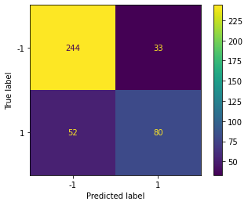

```python
disp = ConfusionMatrixDisplay(confusion_matrix=confusion_matrix(y1_test, LR.predict(x1_test)),
                              display_labels=LR.classes_)
disp.plot()
```

Here is the confusion Matrix. With this matrix we can have easily access to the number of false negative (FN) and false positive(FP). From left to rigth and top to bottom we have, TN, FP, FN and TP.

In our case the false positive rate is not very important. If the algorithm is wrong, says that a patient is positive, there will be additional tests to verify this. On the other hand, if the algorithm says that a patient is negative when he is positive, the patient will go home believing that he is healthy. For each case of detection of a disease in the medical environment (e.g. COVID) the FNR must be as low as possible.

With a linear algorithm you can do this kind of customization, with a non linear one it's more difficult.

Here there are 52 false negative patients with the logistic regression algorithm. Let's transform this value into a rate to realize its importance.

```python
def FNR(confusion_matrix):
    tn, fp, fn, tp = confusion_matrix.ravel()
    return fn/(fn+tp)

def FPR(confusion_matrix):
    tn, fp, fn, tp = confusion_matrix.ravel()
    return fp/(fp+tn)

FNR(confusion_matrix(y1_test, LR.predict(x1_test)))
```

```
0.3939393939393939
```

This value is important, too in a case of disease detection. The lab proposes that we modify the intercept of the linear function to lower this rate. Let's test it.

```python
LR.intercept_
```

```
array([-0.49680147])
```

```python
intercept_list = np.linspace(-3,1, 100)
```

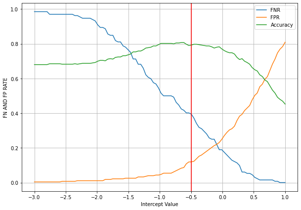

```python
FNR_list = []
FPR_list = []
accuracy_list = []
LR = LogisticRegression(C=grid_search_LR.best_params_['C'],
                        penalty=grid_search_LR.best_params_['penalty'],
                        solver=grid_search_LR.best_params_['solver'])
LR.fit(x1_train, y1_train)
for intercept in intercept_list:
    LR.intercept_ = intercept
    FNR_list.append(FNR(confusion_matrix(y1_test, LR.predict(x1_test))))
    FPR_list.append(FPR(confusion_matrix(y1_test, LR.predict(x1_test))))
    accuracy_list.append(accuracy_score(y1_test, LR.predict(x1_test)))
fig = pl.subplots(1, figsize=(10,7))
pl.plot(intercept_list,FNR_list, label='FNR')
pl.plot(intercept_list,FPR_list, label='FPR')
pl.plot(intercept_list,accuracy_list, label='Accuracy')
pl.axvline(x=-0.49679099, c='r')
pl.legend()
pl.xlabel('Intercept Value')
pl.ylabel('FN AND FP RATE')
pl.grid()
FNR_list = np.array(FNR_list)
```

In red we can see the original value of the intercept, which correspond to an FNR of 0.39.

We see that if we increase the value of the intercept, we can decrease the value of the FNR. This is what we are interested in. But this will also increase the value of the FPR. You have to find the right balance depending on the problem.

I also added the global accuracy on the graph. We notice that SKlearn probably chose the value of the intercept by taking the maximum value of the accuracy, without taking into account the FN and FP rates, it seems logical.

We will now take the value of the intercept which allows to have the FNR lower than 0.1 but without increasing too much the FPR:

```python
np.where(FNR_list<0.1)
```

```
(array([81, 82, 83, 84, 85, 86, 87, 88, 89, 90, 91, 92, 93, 94, 95, 96, 97,
        98, 99]),)
```

Here, we find the indices that allow us to have the FNR below 0.1. Let's take the lowest of this list in order to not loose so much in accuracy and not to increase the FNR too much.

```python
LR.intercept_ = intercept_list[np.where(FNR_list<0.1)[0][0]] # we modify the intercept
```

```python
FNR(confusion_matrix(y1_test, LR.predict(x1_test)))
```

```
0.09848484848484848
```

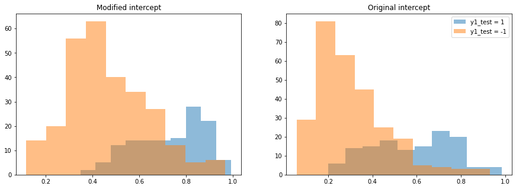

```python
figure, axis = pl.subplots(1,2,figsize=(15,5))
axis[0].hist(LR.predict_proba(x1_test)[y1_test==1,1], label='y1_test = 1', alpha=0.5)
axis[0].hist(LR.predict_proba(x1_test)[y1_test==-1,1], label='y1_test = -1', alpha=0.5)
axis[0].set_title('Modified intercept')

axis[1].hist(LR_predict_proba_default_intercept[y1_test==1,1], label='y1_test = 1', alpha=0.5)
axis[1].hist(LR_predict_proba_default_intercept[y1_test==-1,1], label='y1_test = -1', alpha=0.5)
axis[1].set_title('Original intercept')
fig = pl.legend()
```

We can see that the modification of the intercept has changed the position of the two histograms. There are many more false positives but many less false negatives.

```
<sklearn.metrics._plot.confusion_matrix.ConfusionMatrixDisplay at 0x7fccd0148730>
```

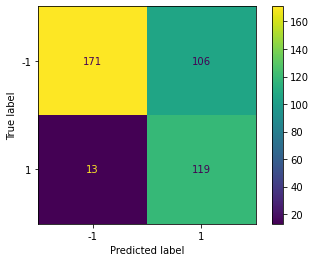

```python
disp = ConfusionMatrixDisplay(confusion_matrix=confusion_matrix(y1_test, LR.predict(x1_test)),
                              display_labels=LR.classes_)
disp.plot()
```

# II- MNIST data

We create a dataframe in order to store our results.

```python
data = {'Algorithm':[],

        'Accuracy (test set)': []
       }

df_mnist = pd.DataFrame(data)

def print_all_measures_mnist():
    print(tabulate(round(df_mnist, 2), headers='keys', tablefmt='pretty',showindex=False))
```

```python
def print_performance_on_test_mnist(clf, df ,algorithm_name_for_df_save=''):
    accuracy = accuracy_score(y2_test, clf.predict(x2_test))
    print('Accuracy on test = ', accuracy)

    if len(algorithm_name_for_df_save) > 0:
        df = df.append({'Algorithm' : algorithm_name_for_df_save,

                'Accuracy (test set)' : accuracy
               }, ignore_index=True)
        return df
```

## II.1- Loading the data

```python
digit_dataset = np.load('digits.npz')
```

```python
for column_name in digit_dataset:
    print(column_name)
```

```
xt
yt
y
x
```

```python
x2_train = digit_dataset['xt'] / 255
y2_train = digit_dataset['yt'].ravel()

x2_test  = digit_dataset['x'] / 255
y2_test  = digit_dataset['y'].ravel()
```

We normalize the data variables in order to have values between 0 and 1.

```python
print('x2_train shape', x2_train.shape)
print('y2_train shape', y2_train.shape)
print('-----')
print('x2_test shape', x2_test.shape)
print('y2_test shape', y2_test.shape)
```

```
x2_train shape (1500, 784)
y2_train shape (1500,)
-----
x2_test shape (3000, 784)
y2_test shape (3000,)
```

```python
np.unique(y2_train, return_counts=True)
```

```
(array([1, 7, 8], dtype=uint8), array([500, 500, 500]))
```

We already know this data set, there is the same number of elements in each class.

## II.2 - Evaluate the different supervised methods

### Linear Discriminant Analysis (LDA)

```python
LDA_mnist = LinearDiscriminantAnalysis()
LDA_mnist.fit(x2_train, y2_train)
df_mnist = print_performance_on_test_mnist(LDA_mnist, df_mnist,'LDA default')
```

```
Accuracy on test =  0.897
```

Now we'll just look at the accuracy. We no longer look at the AUC score knowing that there are now 3 classes.

```python
param_grid = {'solver' : ['lsqr'],
             'shrinkage' : np.linspace(0,1,10)}
grid_search_LDA_mnist = GridSearchCV(LDA, param_grid=param_grid)
no_display = grid_search_LDA_mnist.fit(x2_train, y2_train)
```

We lauch a Grid Search CV with differents valuers of parameters. For some algortihmes it was very long to run so I had to reduce the number of parameters to test.

```python
grid_search_LDA_mnist.best_params_
```

```
{'shrinkage': 0.3333333333333333, 'solver': 'lsqr'}
```

```python
LDA_mnist = LinearDiscriminantAnalysis(shrinkage=grid_search_LDA.best_params_['shrinkage'],
                                 solver=grid_search_LDA.best_params_['solver'])
LDA_mnist.fit(x2_train, y2_train)
df_mnist = print_performance_on_test_mnist(LDA_mnist, df_mnist,'LDA')
```

```
Accuracy on test =  0.9576666666666667
```

We went from 0.897 of accuracy to 0.957 thanks to the change of parameters. For almost all algorithms so far we have managed to gain a lot of accuracy by finding parameters that fit the data. The default settings are not always (and even rarely) the best.

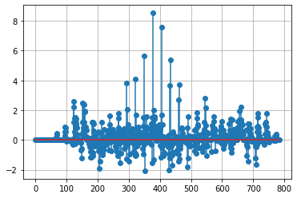

```python
pl.stem(LDA_mnist.coef_[0])
pl.grid()
```

Here I wanted to plot a stem of the weights found by the linear classifier. We can see that it favors the middle pixels, where the numbers are written.

This is a particularity of the MNIST dataset, all numbers are about the same size, and written with the same position on the images. This explains the very good results obtained by the classification algorithms. 0.95 of accuracy is indeed quite high for LDA.

```python
print_all_measures_mnist()
```

```
+-------------+---------------------+
|  Algorithm  | Accuracy (test set) |
+-------------+---------------------+
| LDA default |         0.9         |
|     LDA     |        0.96         |
+-------------+---------------------+
```

Again, we see that LDA has made very good results. Let's try to do better.

### Logistic regression classifier

```python
LR_mnist = LogisticRegression(max_iter=1000)
LR_mnist.fit(x2_train, y2_train)
df_mnist = print_performance_on_test_mnist(LR_mnist, df_mnist,'LR default')
```

```
Accuracy on test =  0.9713333333333334
```

LR is better than LDA with default parameters.

```python
param_grid = {'C' : np.logspace(-1,2,3),
              'penalty': ['l1'],
              'solver' : ['liblinear']}
grid_search_LR_mnist = GridSearchCV(LR_mnist, param_grid=param_grid)
no_display = grid_search_LR_mnist.fit(x2_train, y2_train)
```

```python
grid_search_LR_mnist.best_params_
```

```
{'C': 100.0, 'penalty': 'l1', 'solver': 'liblinear'}
```

```python
LR_mnist = LogisticRegression(C=grid_search_LR_mnist.best_params_['C'],
                        penalty=grid_search_LR_mnist.best_params_['penalty'],
                        solver=grid_search_LR_mnist.best_params_['solver'])
LR_mnist.fit(x2_train, y2_train)
df_mnist = print_performance_on_test_mnist(LR_mnist, df_mnist,'LR')
```

```
Accuracy on test =  0.9663333333333334
```

With the best parameters found, LR is a little bit better than LDA.

```python
print_all_measures_mnist()
```

```
+-------------+---------------------+
|  Algorithm  | Accuracy (test set) |
+-------------+---------------------+
| LDA default |         0.9         |
|     LDA     |        0.96         |
| LR default  |        0.97         |
|     LR      |        0.97         |
+-------------+---------------------+
```

LDA and LR both perform very well.

Let's try a support vector classification.

### SVC

```python
svc_mnist = SVC()
```

```python
svc_mnist.fit(x2_train, y2_train)
```

```
SVC()
```

```python
df_mnist = print_performance_on_test_mnist(svc_mnist, df_mnist,'SVC default')
```

```
Accuracy on test =  0.986
```

```python
param_grid = {'C': [0.1, 1.0, 10, 100, 1000],
              'gamma': ['scale'],
              'kernel': ['rbf']}
```

```python
grid_search_svc_mnist = GridSearchCV(svc_mnist, param_grid=param_grid)
no_display = grid_search_svc_mnist.fit(x2_train, y2_train)
```

```python
grid_search_svc_mnist.best_params_
```

```
{'C': 10, 'gamma': 'scale', 'kernel': 'rbf'}
```

```python
svc_mnist = SVC(probability=True,
         C = grid_search_svc_mnist.best_params_['C'],
         gamma = grid_search_svc_mnist.best_params_['gamma'],
         kernel = grid_search_svc_mnist.best_params_['kernel'],)
svc_mnist.fit(x2_train, y2_train)
```

```
SVC(C=10, probability=True)
```

```python
df_mnist = print_performance_on_test_mnist(svc_mnist, df_mnist,'SVC')
```

```
Accuracy on test =  0.9863333333333333
```

Here, it's a little bit different since it was difficult to find parameters that increase the accuracy. The default parameters work very well.

### MLPClassifier

```python
mlp_classifier_mnist = MLPClassifier()
```

```python
mlp_classifier_mnist.fit(x2_train, y2_train)
```

```
MLPClassifier()
```

```python
df_mnist = print_performance_on_test_mnist(mlp_classifier_mnist, df_mnist,'MLP default')
```

```
Accuracy on test =  0.9806666666666667
```

```python
param_grid = {'solver': ['adam', 'sgd'],
              'max_iter': [3000],
              'random_state' : [0],
              'alpha': np.logspace(-5,-1,10),
              'hidden_layer_sizes':np.arange(10, 16,2)
             }
```

```python
grid_search_mlp_mnist = GridSearchCV(mlp_classifier_mnist, param_grid=param_grid)
no_display = grid_search_mlp_mnist.fit(x1_train, y1_train)
```

```python
grid_search_mlp_mnist.best_params_
```

```
{'alpha': 1e-05,
 'hidden_layer_sizes': 12,
 'max_iter': 3000,
 'random_state': 0,
 'solver': 'sgd'}
```

```python
mlp_classifier_mnist = MLPClassifier(max_iter=2000,
                              alpha = grid_search_mlp_mnist.best_params_['alpha'],
                              solver = grid_search_mlp_mnist.best_params_['solver'],
                              hidden_layer_sizes = grid_search_mlp_mnist.best_params_['hidden_layer_sizes'])
mlp_classifier_mnist.fit(x2_train, y2_train)
```

```
MLPClassifier(alpha=1e-05, hidden_layer_sizes=12, max_iter=2000, solver='sgd')
```

```python
df_mnist = print_performance_on_test_mnist(mlp_classifier_mnist, df_mnist,'MLP')
```

```
Accuracy on test =  0.9716666666666667
```

Again, It is still difficult to find parameters that increase performance. We will keep SVC which has obtained the best results so far.

## II.3 - Interpreting the classifier

```python
print_all_measures_mnist()
```

```
+-------------+---------------------+
|  Algorithm  | Accuracy (test set) |
+-------------+---------------------+
| LDA default |         0.9         |
|     LDA     |        0.96         |
| LR default  |        0.97         |
|     LR      |        0.97         |
| SVC default |        0.99         |
|     SVC     |        0.99         |
| MLP default |        0.98         |
|     MLP     |        0.97         |
+-------------+---------------------+
```

If we look at the accuracy, all the algorithms are really good on this dataset. SVC performs better with an accuracy of 0.99 on test data. It looks like very good.

```python
from sklearn.metrics.cluster import adjusted_rand_score
print('ARS LDA: ',adjusted_rand_score(y2_test, LDA_mnist.predict(x2_test)))
print('ARS LR: ',adjusted_rand_score(y2_test, LR_mnist.predict(x2_test)))
print('ARS SVC: ',adjusted_rand_score(y2_test, svc_mnist.predict(x2_test)))
print('ARS MLP: ',adjusted_rand_score(y2_test, mlp_classifier_mnist.predict(x2_test)))
```

```
ARS LDA:  0.8780763867197667
ARS LR:  0.9019611747232245
ARS SVC:  0.9594381063460441
ARS MLP:  0.9169634868644835
```

Out of curiosity, I calculated the adjusted rand score to see if it could be useful outside of clustering. Once again, SVC gets the maximum score. So we will keep this algorithm for the rest of the Lab.

```
<sklearn.metrics._plot.confusion_matrix.ConfusionMatrixDisplay at 0x7fccb713cca0>
```

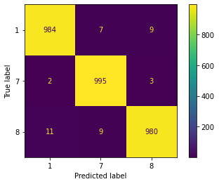

```python
disp = ConfusionMatrixDisplay(confusion_matrix=confusion_matrix(y2_test, svc_mnist.predict(x2_test)),
                              display_labels=svc_mnist.classes_)
disp.plot()
```

Let's look at the confusion matrix given by the SVC algorithm on test dataset:

- The highest number of errors corresponds to 8 that were predicted in 1. We will look at how this is possible afterwards, and what styles of 8 may have been miss classified.
- Then in second position, there are 8 predicted in 7 and 1 predicted in 8.
- Then there are 1 miss-predicted in 7, which is for me the most logical missclassification. Indeed as a human being it can be easier to make a mistake between a 7 and a 1 than between an 8 and a 1.

Now let's try to display its misclassified numbers:

```python
pred_mnist = svc_mnist.predict(x2_test)
true_mnist = y2_test
```

```python
miss_classified_mnist = []
miss_classified_mnist_pred_labels = []
miss_classified_mnist_true_labels = []
for i in range(len(true_mnist)):
    if true_mnist[i] != pred_mnist[i]:
        miss_classified_mnist.append(x2_test[i])
        miss_classified_mnist_pred_labels.append(pred_mnist[i])
        miss_classified_mnist_true_labels.append(true_mnist[i])
miss_classified_mnist = np.array(miss_classified_mnist)
miss_classified_mnist_pred_labels = np.array(miss_classified_mnist_pred_labels)
miss_classified_mnist_true_labels = np.array(miss_classified_mnist_true_labels)
```

```python
print(miss_classified_mnist.shape)
print(miss_classified_mnist_pred_labels.shape)
print(miss_classified_mnist_true_labels.shape)
```

```
(41, 784)
(41,)
(41,)
```

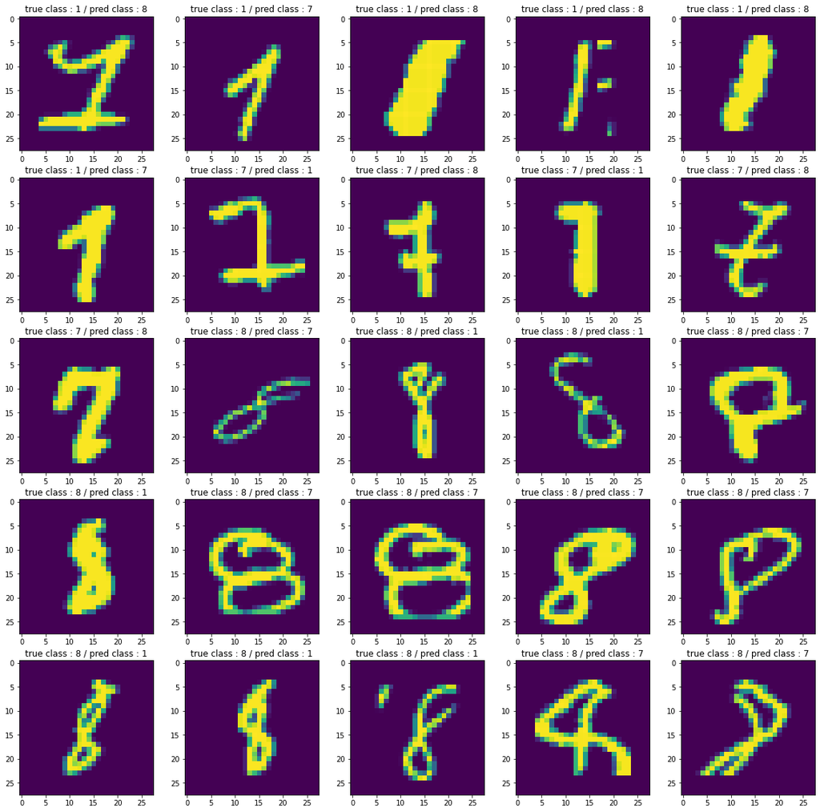

```python
figure, axis = pl.subplots(5,5, figsize=(20,20))
index = 10 # on commence à 10 pour avoir des images intéréssantes
for l in range(5):
    for c in range(5):
        axis[l][c].imshow(miss_classified_mnist[index].reshape(28,28))
        axis[l][c].set_title('true class : {} / pred class : {}'.format(miss_classified_mnist_true_labels[index],miss_classified_mnist_pred_labels[index]))
        index += 1
```

Looking at the classified miss samples, we can say :

- Almost all misclassifieds have quite special forms, it is not illogical that they have been mispredicted.
- The 8 predicted in 1 are very thin 8.
- The 1 with rounding borders are transformed into 7.
- The very thick 1 are transformed into 8.

Looking at these examples, I would say that the limitation of the algorithm is that it looks at pixels by pixels, it does not look at the whole image. A CNN might be more efficient on weird written numbers, it would look at the patterns that correspond to a given class like a human being would.

#### Adversarial samples

Let's take a well classified image.

```python
well_classifier = x2_test[pred_mnist == true_mnist]
well_classifier_labels = y2_test[pred_mnist == true_mnist]
```

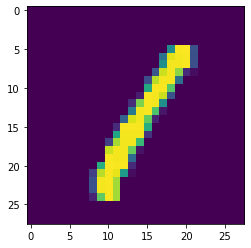

```python
image = well_classifier[0]
label = well_classifier_labels[0]
pl.imshow(image.reshape(28,28))
```

```python
label
```

```
1
```

I added some noise on the image. I tried a lot of values with a lot of different numbers, I had a hard time to get an accuracy not equal to 1. I find that the algorithm is quite efficient on this kind of adversarial sample.

```python
adversarial_samples = []
for i in range(1000):
    adversarial_samples.append(image + 0.25 * np.random.randn(784))
```

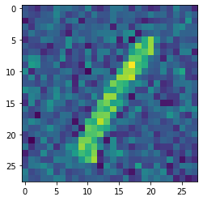

```python
pl.imshow(adversarial_samples[0].reshape(28,28))
```

We always distinguish the 1.

```python
accuracy_score([label for i in range(1000)],svc_mnist.predict(adversarial_samples))
```

```
0.86
```

The accuracy has gone down well, this shows that the adversarial sample has worked well.

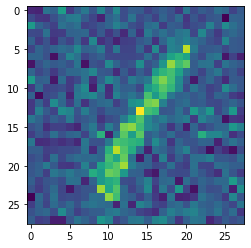

```python
adversarial_samples = np.array(adversarial_samples)
pl.imshow(adversarial_samples[[label for i in range(1000)] != svc_mnist.predict(adversarial_samples)][0].reshape(28,28))
```

Here we see a sample that the algorithm has misclassified, it looks very similar to the previous one but is perhaps a little more blurred.

Let's add more noise to see the effect:

```python
adversarial_samples = []
for i in range(1000):
    adversarial_samples.append(image + 0.3 * np.random.randn(784))
```

```python
accuracy_score([label for i in range(1000)],svc_mnist.predict(adversarial_samples))
```

```
0.133
```

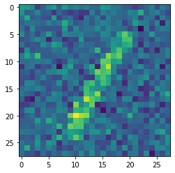

```python
pl.imshow(adversarial_samples[0].reshape(28,28))
```

With a coefficient of 0.3, we reach the limits of the algorithm. However it is still possible as a human being to distinguish that it is a 1. Let's now try to train a CNN to see if it will do better on sample adversarial.

## II.4 - CNN

We use Keras with a Conv2D layer.

```python
import tensorflow as tf
from tensorflow.keras.utils import to_categorical
from tensorflow.keras.models import Sequential, Model
from tensorflow.keras.layers import Dense, Dropout, Activation, Flatten, Input
from tensorflow.keras.layers import Conv2D, MaxPooling2D
from tensorflow.keras import optimizers
```

```python
x2_train_cnn = x2_train.reshape(x2_train.shape[0], 28, 28,1)
x2_test_cnn = x2_test.reshape(x2_test.shape[0], 28, 28,1)
x2_train_cnn.shape
```

```
(1500, 28, 28, 1)
```

```python
y2_train_cnn = to_categorical(y2_train)
y2_test_cnn = to_categorical(y2_test)
y2_train_cnn.shape
```

```
(1500, 9)
```

I reshaped the data and I put the labels as one hot vectors.

```python
learning_rate = 0.01
n_epochs = 10
batch_size = 32
nb_filters = 64
kernel_size = (4, 4)
pool_size = (2, 2)

img_rows, img_cols, nb_channels = x2_train_cnn.shape[1], x2_train_cnn.shape[2], 1

n_h_0 = nb_channels
n_h_1 = nb_filters
n_h_2 = nb_filters
```

```python
model = Sequential()

model.add(Conv2D(nb_filters, kernel_size=kernel_size, input_shape=(img_rows, img_cols, nb_channels), activation='relu',strides=(1, 1) , name='Conv1', padding='same'))
model.add(Conv2D(nb_filters, kernel_size=kernel_size, input_shape=(img_rows, img_cols,n_h_1),activation='relu',strides=(1, 1) , name='Conv2', padding='same'))
model.add(MaxPooling2D(pool_size=(2, 2),strides=(2, 2), name='MaxPool1'))
model.add(Flatten(name='Flatten1'))
model.add(Dense(y2_train_cnn.shape[1], activation='softmax',name='Dense1'))
```

```python
model.summary()
```

```
Model: "sequential"
_________________________________________________________________
Layer (type)                 Output Shape              Param #
=================================================================
Conv1 (Conv2D)               (None, 28, 28, 64)        1088
_________________________________________________________________
Conv2 (Conv2D)               (None, 28, 28, 64)        65600
_________________________________________________________________
MaxPool1 (MaxPooling2D)      (None, 14, 14, 64)        0
_________________________________________________________________
Flatten1 (Flatten)           (None, 12544)             0
_________________________________________________________________
Dense1 (Dense)               (None, 9)                 112905
=================================================================
Total params: 179,593
Trainable params: 179,593
Non-trainable params: 0
_________________________________________________________________
```

here is the model, two Conv2D, one Max pooling in order to have shift invariant, one Flatten and one Dense layer.

```python
model.compile(optimizer='adam',
              loss='categorical_crossentropy',
              metrics=['accuracy'])

model.fit(x2_train_cnn, y2_train_cnn, epochs=n_epochs, batch_size=batch_size, validation_data=(x2_test_cnn, y2_test_cnn))

score = model.evaluate(x2_test_cnn, y2_test_cnn, verbose=False)
print('Test loss:', score[0])
print('Test accuracy:', score[1])
```

```
Test loss: 0.09379914402961731
Test accuracy: 0.9810000061988831
```

With these layers and parameters the accuracy is almost equal to the SVC on the test data. What I would like to see now is if the algorithm is more robust to adversarial samples.

**On adversarial samples (coef : 0.25):**

```python
adversarial_samples = []
for i in range(1000):
    adversarial_samples.append(image + 0.25 * np.random.randn(784))
adversarial_samples = np.array(adversarial_samples)
```

```python
adversarial_samples_cnn = adversarial_samples.reshape(adversarial_samples.shape[0], 28, 28, 1)
label_categorical = [0 for i in range(9)]
label_categorical[label] = 1
adversarial_samples_labels_cnn = np.array([label_categorical for i in range(1000)])
print(adversarial_samples_cnn.shape)
print(adversarial_samples_labels_cnn.shape)
```

```
(1000, 28, 28, 1)
(1000, 9)
```

```python
score = model.evaluate(adversarial_samples_cnn, adversarial_samples_labels_cnn, verbose=False)
print('Test accuracy:', score[1])
```

```
Test accuracy: 0.9909999966621399
```

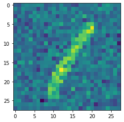

```python
pl.imshow(adversarial_samples[0].reshape(28,28))
```

**On adversarial samples (coef : 0.3):**

```python
adversarial_samples = []
for i in range(1000):
    adversarial_samples.append(image + 0.3 * np.random.randn(784))
adversarial_samples = np.array(adversarial_samples)
```

```python
adversarial_samples_cnn = adversarial_samples.reshape(adversarial_samples.shape[0], 28, 28, 1)
label_categorical = [0 for i in range(9)]
label_categorical[label] = 1
adversarial_samples_labels_cnn = np.array([label_categorical for i in range(1000)])
print(adversarial_samples_cnn.shape)
print(adversarial_samples_labels_cnn.shape)
```

```
(1000, 28, 28, 1)
(1000, 9)
```

```python
score = model.evaluate(adversarial_samples_cnn, adversarial_samples_labels_cnn, verbose=False)
print('Test accuracy:', score[1])
```

```
Test accuracy: 0.9139999747276306
```

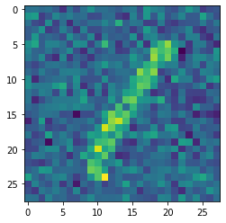

```python
pl.imshow(adversarial_samples[0].reshape(28,28))
```

**On adversarial samples (coef : 0.5):**

```python
adversarial_samples = []
for i in range(1000):
    adversarial_samples.append(image + 0.5 * np.random.randn(784))
adversarial_samples = np.array(adversarial_samples)
```

```python
adversarial_samples_cnn = adversarial_samples.reshape(adversarial_samples.shape[0], 28, 28, 1)
label_categorical = [0 for i in range(9)]
label_categorical[label] = 1
adversarial_samples_labels_cnn = np.array([label_categorical for i in range(1000)])
print(adversarial_samples_cnn.shape)
print(adversarial_samples_labels_cnn.shape)
```

```
(1000, 28, 28, 1)
(1000, 9)
```

```python
score = model.evaluate(adversarial_samples_cnn, adversarial_samples_labels_cnn, verbose=False)
print('Test accuracy:', score[1])
```

```
Test accuracy: 0.421999990940094
```

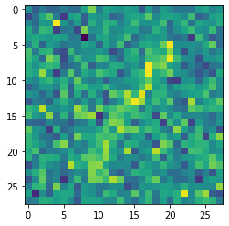

```python
pl.imshow(adversarial_samples[0].reshape(28,28))
```

However, it is important to keep in mind that we are dealing with very simple images and that it is always possible to create adversarial samples specific to a CNN.

# Conclusion

I really enjoyed working on this lab and all the others. From this LAB I will remember that it is not always the accuracy or the performance indicators that count. Other factors are also important like the false negative rate or the resistance to adversarial samples.

I will also remember that even if sklearn seems at first sight to be like a magic black box that allows you to obtain results very quickly, you have to remain curious about its functioning. First by trying to find optimal parameters and then by knowing that it is possible to act on other more hidden parameters such as the intercept.

Even if this course is over, I will continue to practice as much as possible because I am very interested about this discipline. I heard about the kaggle website which can be a good tool for regular training with its competitions. But I think the problem with this site is that you are only rated on the accuracy rendered by your algorithm. Nevertheless, it surely allows to gain experience.

I am this year in apprenticeship and I work on the Google cloud tools. So in parallel to the course I was interested in the existing cloud tools related to machine learning, there are many. I can mention BigQuey ML, Vertex AI, and others. So I will have the opportunity to learn these tools in more detail during the year.